# Risk Factor Analysis

## Outcome Variable

**Outcome Variable:** ever_wasted

## Predictor Variables

**Intervention Variable:** impfloor

**Adjustment Set:**

- arm
- sex
- W_mage
- meducyrs
- feducyrs
- hhwealth_quart
- hfoodsec
- W_mhtcm
- W_nrooms
- W_nchldlt5
- W_parity
- impsan
- safeh20
- delta_W_mage
- delta_meducyrs
- delta_feducyrs
- delta_hhwealth_quart
- delta_hfoodsec
- delta_W_mhtcm
- delta_W_nrooms
- delta_W_nchldlt5
- delta_W_parity
- delta_impsan
- delta_safeh20

## Stratifying Variables

The analysis was stratified on these variable(s):

- agecat
- studyid
- country

## Data Summary

| agecat | studyid | country | impfloor | ever_wasted | n_cell | n |
| --- | --- | --- | --- | --- | --- | --- |
| 0-24 months (no birth wast) | ki0047075b-MAL-ED | BANGLADESH | 0 | 0 | 12 | 242 |
| 0-24 months (no birth wast) | ki0047075b-MAL-ED | BANGLADESH | 0 | 1 | 7 | 242 |
| 0-24 months (no birth wast) | ki0047075b-MAL-ED | BANGLADESH | 1 | 0 | 173 | 242 |
| 0-24 months (no birth wast) | ki0047075b-MAL-ED | BANGLADESH | 1 | 1 | 50 | 242 |
| 0-24 months (no birth wast) | ki0047075b-MAL-ED | BRAZIL | 0 | 0 | 2 | 209 |
| 0-24 months (no birth wast) | ki0047075b-MAL-ED | BRAZIL | 0 | 1 | 0 | 209 |
| 0-24 months (no birth wast) | ki0047075b-MAL-ED | BRAZIL | 1 | 0 | 195 | 209 |
| 0-24 months (no birth wast) | ki0047075b-MAL-ED | BRAZIL | 1 | 1 | 12 | 209 |
| 0-24 months (no birth wast) | ki0047075b-MAL-ED | INDIA | 0 | 0 | 8 | 231 |
| 0-24 months (no birth wast) | ki0047075b-MAL-ED | INDIA | 0 | 1 | 7 | 231 |
| 0-24 months (no birth wast) | ki0047075b-MAL-ED | INDIA | 1 | 0 | 136 | 231 |
| 0-24 months (no birth wast) | ki0047075b-MAL-ED | INDIA | 1 | 1 | 80 | 231 |
| 0-24 months (no birth wast) | ki0047075b-MAL-ED | NEPAL | 0 | 0 | 103 | 229 |
| 0-24 months (no birth wast) | ki0047075b-MAL-ED | NEPAL | 0 | 1 | 23 | 229 |
| 0-24 months (no birth wast) | ki0047075b-MAL-ED | NEPAL | 1 | 0 | 86 | 229 |
| 0-24 months (no birth wast) | ki0047075b-MAL-ED | NEPAL | 1 | 1 | 17 | 229 |
| 0-24 months (no birth wast) | ki0047075b-MAL-ED | PERU | 0 | 0 | 197 | 272 |
| 0-24 months (no birth wast) | ki0047075b-MAL-ED | PERU | 0 | 1 | 16 | 272 |
| 0-24 months (no birth wast) | ki0047075b-MAL-ED | PERU | 1 | 0 | 55 | 272 |
| 0-24 months (no birth wast) | ki0047075b-MAL-ED | PERU | 1 | 1 | 4 | 272 |
| 0-24 months (no birth wast) | ki0047075b-MAL-ED | SOUTH AFRICA | 0 | 0 | 18 | 257 |
| 0-24 months (no birth wast) | ki0047075b-MAL-ED | SOUTH AFRICA | 0 | 1 | 3 | 257 |
| 0-24 months (no birth wast) | ki0047075b-MAL-ED | SOUTH AFRICA | 1 | 0 | 196 | 257 |
| 0-24 months (no birth wast) | ki0047075b-MAL-ED | SOUTH AFRICA | 1 | 1 | 40 | 257 |
| 0-24 months (no birth wast) | ki0047075b-MAL-ED | TANZANIA, UNITED REPUBLIC OF | 0 | 0 | 205 | 248 |
| 0-24 months (no birth wast) | ki0047075b-MAL-ED | TANZANIA, UNITED REPUBLIC OF | 0 | 1 | 29 | 248 |
| 0-24 months (no birth wast) | ki0047075b-MAL-ED | TANZANIA, UNITED REPUBLIC OF | 1 | 0 | 13 | 248 |
| 0-24 months (no birth wast) | ki0047075b-MAL-ED | TANZANIA, UNITED REPUBLIC OF | 1 | 1 | 1 | 248 |
| 0-24 months (no birth wast) | ki1000108-CMC-V-BCS-2002 | INDIA | 0 | 0 | 0 | 258 |
| 0-24 months (no birth wast) | ki1000108-CMC-V-BCS-2002 | INDIA | 0 | 1 | 0 | 258 |

[output cut: 162 more lines]

The following strata were considered:

- agecat: 0-24 months (no birth wast), studyid: ki0047075b-MAL-ED, country: BANGLADESH
- agecat: 0-24 months (no birth wast), studyid: ki0047075b-MAL-ED, country: BRAZIL
- agecat: 0-24 months (no birth wast), studyid: ki0047075b-MAL-ED, country: INDIA
- agecat: 0-24 months (no birth wast), studyid: ki0047075b-MAL-ED, country: NEPAL
- agecat: 0-24 months (no birth wast), studyid: ki0047075b-MAL-ED, country: PERU
- agecat: 0-24 months (no birth wast), studyid: ki0047075b-MAL-ED, country: SOUTH AFRICA
- agecat: 0-24 months (no birth wast), studyid: ki0047075b-MAL-ED, country: TANZANIA, UNITED REPUBLIC OF
- agecat: 0-24 months (no birth wast), studyid: ki1000108-CMC-V-BCS-2002, country: INDIA
- agecat: 0-24 months (no birth wast), studyid: ki1000108-IRC, country: INDIA
- agecat: 0-24 months (no birth wast), studyid: ki1017093-NIH-Birth, country: BANGLADESH
- agecat: 0-24 months (no birth wast), studyid: ki1017093b-PROVIDE, country: BANGLADESH
- agecat: 0-24 months (no birth wast), studyid: ki1017093c-NIH-Crypto, country: BANGLADESH
- agecat: 0-24 months (no birth wast), studyid: ki1113344-GMS-Nepal, country: NEPAL
- agecat: 0-24 months (no birth wast), studyid: ki1114097-CONTENT, country: PERU
- agecat: 0-24 months (no birth wast), studyid: kiGH5241-JiVitA-3, country: BANGLADESH
- agecat: 0-24 months (no birth wast), studyid: kiGH5241-JiVitA-4, country: BANGLADESH
- agecat: 0-6 months (no birth wast), studyid: ki0047075b-MAL-ED, country: BANGLADESH
- agecat: 0-6 months (no birth wast), studyid: ki0047075b-MAL-ED, country: BRAZIL
- agecat: 0-6 months (no birth wast), studyid: ki0047075b-MAL-ED, country: INDIA
- agecat: 0-6 months (no birth wast), studyid: ki0047075b-MAL-ED, country: NEPAL
- agecat: 0-6 months (no birth wast), studyid: ki0047075b-MAL-ED, country: PERU
- agecat: 0-6 months (no birth wast), studyid: ki0047075b-MAL-ED, country: SOUTH AFRICA
- agecat: 0-6 months (no birth wast), studyid: ki0047075b-MAL-ED, country: TANZANIA, UNITED REPUBLIC OF
- agecat: 0-6 months (no birth wast), studyid: ki1000108-CMC-V-BCS-2002, country: INDIA
- agecat: 0-6 months (no birth wast), studyid: ki1000108-IRC, country: INDIA
- agecat: 0-6 months (no birth wast), studyid: ki1017093-NIH-Birth, country: BANGLADESH
- agecat: 0-6 months (no birth wast), studyid: ki1017093b-PROVIDE, country: BANGLADESH
- agecat: 0-6 months (no birth wast), studyid: ki1017093c-NIH-Crypto, country: BANGLADESH
- agecat: 0-6 months (no birth wast), studyid: ki1113344-GMS-Nepal, country: NEPAL
- agecat: 0-6 months (no birth wast), studyid: ki1114097-CONTENT, country: PERU
- agecat: 0-6 months (no birth wast), studyid: kiGH5241-JiVitA-3, country: BANGLADESH
- agecat: 0-6 months (no birth wast), studyid: kiGH5241-JiVitA-4, country: BANGLADESH
- agecat: 6-24 months, studyid: ki0047075b-MAL-ED, country: BANGLADESH
- agecat: 6-24 months, studyid: ki0047075b-MAL-ED, country: BRAZIL
- agecat: 6-24 months, studyid: ki0047075b-MAL-ED, country: INDIA
- agecat: 6-24 months, studyid: ki0047075b-MAL-ED, country: NEPAL
- agecat: 6-24 months, studyid: ki0047075b-MAL-ED, country: PERU
- agecat: 6-24 months, studyid: ki0047075b-MAL-ED, country: SOUTH AFRICA
- agecat: 6-24 months, studyid: ki0047075b-MAL-ED, country: TANZANIA, UNITED REPUBLIC OF
- agecat: 6-24 months, studyid: ki1000108-CMC-V-BCS-2002, country: INDIA
- agecat: 6-24 months, studyid: ki1000108-IRC, country: INDIA
- agecat: 6-24 months, studyid: ki1017093-NIH-Birth, country: BANGLADESH
- agecat: 6-24 months, studyid: ki1017093b-PROVIDE, country: BANGLADESH
- agecat: 6-24 months, studyid: ki1017093c-NIH-Crypto, country: BANGLADESH
- agecat: 6-24 months, studyid: ki1113344-GMS-Nepal, country: NEPAL
- agecat: 6-24 months, studyid: ki1114097-CONTENT, country: PERU
- agecat: 6-24 months, studyid: kiGH5241-JiVitA-3, country: BANGLADESH
- agecat: 6-24 months, studyid: kiGH5241-JiVitA-4, country: BANGLADESH

### Dropped Strata

Some strata were dropped due to rare outcomes:

- agecat: 0-24 months (no birth wast), studyid: ki0047075b-MAL-ED, country: BRAZIL
- agecat: 0-24 months (no birth wast), studyid: ki0047075b-MAL-ED, country: PERU
- agecat: 0-24 months (no birth wast), studyid: ki0047075b-MAL-ED, country: SOUTH AFRICA
- agecat: 0-24 months (no birth wast), studyid: ki0047075b-MAL-ED, country: TANZANIA, UNITED REPUBLIC OF
- agecat: 0-24 months (no birth wast), studyid: ki1000108-CMC-V-BCS-2002, country: INDIA
- agecat: 0-24 months (no birth wast), studyid: ki1000108-IRC, country: INDIA
- agecat: 0-24 months (no birth wast), studyid: ki1114097-CONTENT, country: PERU
- agecat: 0-6 months (no birth wast), studyid: ki0047075b-MAL-ED, country: BANGLADESH
- agecat: 0-6 months (no birth wast), studyid: ki0047075b-MAL-ED, country: BRAZIL
- agecat: 0-6 months (no birth wast), studyid: ki0047075b-MAL-ED, country: INDIA
- agecat: 0-6 months (no birth wast), studyid: ki0047075b-MAL-ED, country: PERU
- agecat: 0-6 months (no birth wast), studyid: ki0047075b-MAL-ED, country: SOUTH AFRICA
- agecat: 0-6 months (no birth wast), studyid: ki0047075b-MAL-ED, country: TANZANIA, UNITED REPUBLIC OF
- agecat: 0-6 months (no birth wast), studyid: ki1000108-CMC-V-BCS-2002, country: INDIA
- agecat: 0-6 months (no birth wast), studyid: ki1000108-IRC, country: INDIA
- agecat: 0-6 months (no birth wast), studyid: ki1114097-CONTENT, country: PERU
- agecat: 6-24 months, studyid: ki0047075b-MAL-ED, country: BRAZIL
- agecat: 6-24 months, studyid: ki0047075b-MAL-ED, country: PERU
- agecat: 6-24 months, studyid: ki0047075b-MAL-ED, country: SOUTH AFRICA
- agecat: 6-24 months, studyid: ki0047075b-MAL-ED, country: TANZANIA, UNITED REPUBLIC OF
- agecat: 6-24 months, studyid: ki1000108-CMC-V-BCS-2002, country: INDIA
- agecat: 6-24 months, studyid: ki1000108-IRC, country: INDIA
- agecat: 6-24 months, studyid: ki1114097-CONTENT, country: PERU

## Methods Detail

We’re interested in the causal parameters $E[Y_a]$ for all values of $a \in \mathcal{A}$. These parameters represent the mean outcome if, possibly contrary to fact, we intervened to set all units to have $A=a$. Under the randomization and positivity assumptions, these are identified by the statistical parameters $\psi_a=E_W[E_{Y|A,W}(Y|A=a,W)]$. In addition, we’re interested in the mean of $Y$, $E[Y]$ under no intervention (the observed mean). We will estimate these parameters by using SuperLearner to fit the relevant likelihood factors – $E_{Y|A,W}(Y|A=a,W)$ and $p(A=a|W)$, and then updating our likelihood fit using a joint TMLE.

For unadjusted analyses ($W=\{\}$), initial likelihoods were estimated using Lrnr_glm to estimate the simple $E(Y|A)$ and Lrnr_mean to estimate $p(A)$. For adjusted analyses, a small library containing Lrnr_glmnet, Lrnr_xgboost, and Lrnr_mean was used.

Having estimated these parameters, we will then use the delta method to estimate relative risks and attributable risks relative to a prespecified baseline level of $A$.

# Results Detail

## Results Plots

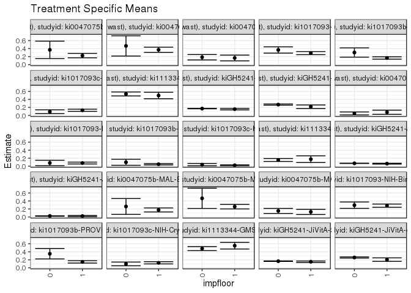

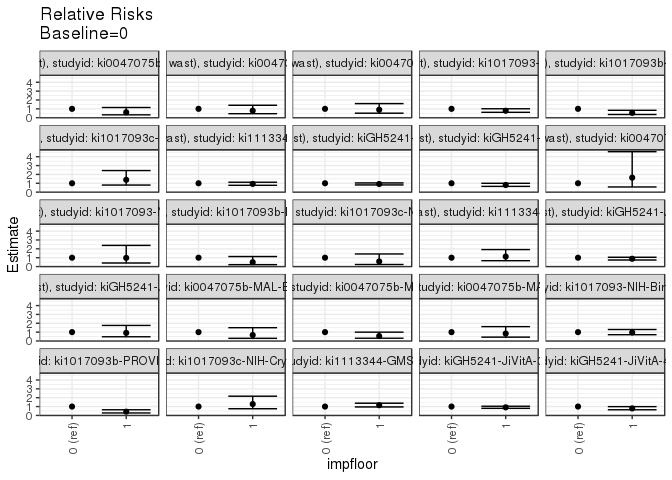

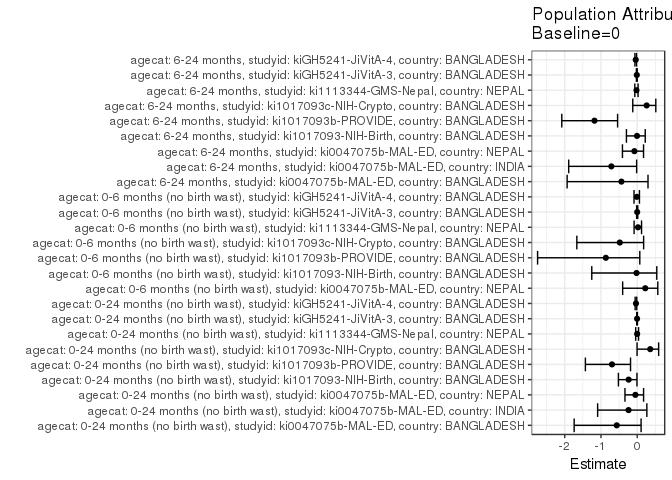

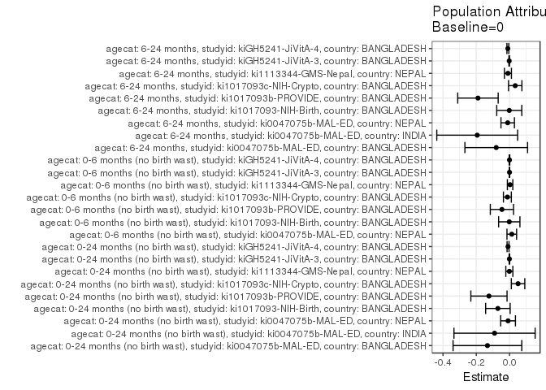

## Results Table

### Parameter: TSM

| agecat | studyid | country | intervention_level | baseline_level | estimate | ci_lower | ci_upper |
| --- | --- | --- | --- | --- | --- | --- | --- |
| 0-24 months (no birth wast) | ki0047075b-MAL-ED | BANGLADESH | 0 | NA | 0.3684211 | 0.1510726 | 0.5857695 |
| 0-24 months (no birth wast) | ki0047075b-MAL-ED | BANGLADESH | 1 | NA | 0.2242152 | 0.1693625 | 0.2790679 |
| 0-24 months (no birth wast) | ki0047075b-MAL-ED | INDIA | 0 | NA | 0.4666667 | 0.2136511 | 0.7196823 |
| 0-24 months (no birth wast) | ki0047075b-MAL-ED | INDIA | 1 | NA | 0.3703704 | 0.3058311 | 0.4349096 |
| 0-24 months (no birth wast) | ki0047075b-MAL-ED | NEPAL | 0 | NA | 0.1834356 | 0.1157414 | 0.2511298 |
| 0-24 months (no birth wast) | ki0047075b-MAL-ED | NEPAL | 1 | NA | 0.1649465 | 0.0931231 | 0.2367700 |
| 0-24 months (no birth wast) | ki1017093-NIH-Birth | BANGLADESH | 0 | NA | 0.3653778 | 0.2868680 | 0.4438875 |
| 0-24 months (no birth wast) | ki1017093-NIH-Birth | BANGLADESH | 1 | NA | 0.2866851 | 0.2486693 | 0.3247008 |
| 0-24 months (no birth wast) | ki1017093b-PROVIDE | BANGLADESH | 0 | NA | 0.3012736 | 0.1853532 | 0.4171939 |
| 0-24 months (no birth wast) | ki1017093b-PROVIDE | BANGLADESH | 1 | NA | 0.1651798 | 0.1361227 | 0.1942369 |
| 0-24 months (no birth wast) | ki1017093c-NIH-Crypto | BANGLADESH | 0 | NA | 0.0917824 | 0.0446424 | 0.1389224 |
| 0-24 months (no birth wast) | ki1017093c-NIH-Crypto | BANGLADESH | 1 | NA | 0.1278233 | 0.1001394 | 0.1555072 |
| 0-24 months (no birth wast) | ki1113344-GMS-Nepal | NEPAL | 0 | NA | 0.5355165 | 0.4861283 | 0.5849047 |
| 0-24 months (no birth wast) | ki1113344-GMS-Nepal | NEPAL | 1 | NA | 0.4969625 | 0.4165791 | 0.5773458 |
| 0-24 months (no birth wast) | kiGH5241-JiVitA-3 | BANGLADESH | 0 | NA | 0.1700429 | 0.1645263 | 0.1755595 |
| 0-24 months (no birth wast) | kiGH5241-JiVitA-3 | BANGLADESH | 1 | NA | 0.1561945 | 0.1375224 | 0.1748666 |
| 0-24 months (no birth wast) | kiGH5241-JiVitA-4 | BANGLADESH | 0 | NA | 0.2691529 | 0.2541076 | 0.2841982 |
| 0-24 months (no birth wast) | kiGH5241-JiVitA-4 | BANGLADESH | 1 | NA | 0.2165707 | 0.1723803 | 0.2607610 |
| 0-6 months (no birth wast) | ki0047075b-MAL-ED | NEPAL | 0 | NA | 0.0480000 | 0.0104430 | 0.0855570 |
| 0-6 months (no birth wast) | ki0047075b-MAL-ED | NEPAL | 1 | NA | 0.0784314 | 0.0261418 | 0.1307210 |
| 0-6 months (no birth wast) | ki1017093-NIH-Birth | BANGLADESH | 0 | NA | 0.0806452 | 0.0128097 | 0.1484807 |
| 0-6 months (no birth wast) | ki1017093-NIH-Birth | BANGLADESH | 1 | NA | 0.0789981 | 0.0557719 | 0.1022242 |
| 0-6 months (no birth wast) | ki1017093b-PROVIDE | BANGLADESH | 0 | NA | 0.0983607 | 0.0235732 | 0.1731481 |
| 0-6 months (no birth wast) | ki1017093b-PROVIDE | BANGLADESH | 1 | NA | 0.0482315 | 0.0313814 | 0.0650816 |
| 0-6 months (no birth wast) | ki1017093c-NIH-Crypto | BANGLADESH | 0 | NA | 0.0395480 | 0.0108170 | 0.0682791 |
| 0-6 months (no birth wast) | ki1017093c-NIH-Crypto | BANGLADESH | 1 | NA | 0.0227273 | 0.0105059 | 0.0349487 |
| 0-6 months (no birth wast) | ki1113344-GMS-Nepal | NEPAL | 0 | NA | 0.1553098 | 0.1182117 | 0.1924079 |
| 0-6 months (no birth wast) | ki1113344-GMS-Nepal | NEPAL | 1 | NA | 0.1750178 | 0.0916710 | 0.2583647 |
| 0-6 months (no birth wast) | kiGH5241-JiVitA-3 | BANGLADESH | 0 | NA | 0.0717393 | 0.0679638 | 0.0755149 |
| 0-6 months (no birth wast) | kiGH5241-JiVitA-3 | BANGLADESH | 1 | NA | 0.0631542 | 0.0525666 | 0.0737418 |
| 0-6 months (no birth wast) | kiGH5241-JiVitA-4 | BANGLADESH | 0 | NA | 0.0255400 | 0.0205787 | 0.0305012 |
| 0-6 months (no birth wast) | kiGH5241-JiVitA-4 | BANGLADESH | 1 | NA | 0.0233787 | 0.0088498 | 0.0379076 |
| 6-24 months | ki0047075b-MAL-ED | BANGLADESH | 0 | NA | 0.2631579 | 0.0647434 | 0.4615724 |
| 6-24 months | ki0047075b-MAL-ED | BANGLADESH | 1 | NA | 0.1764706 | 0.1261049 | 0.2268362 |
| 6-24 months | ki0047075b-MAL-ED | INDIA | 0 | NA | 0.4666667 | 0.2136604 | 0.7196729 |
| 6-24 months | ki0047075b-MAL-ED | INDIA | 1 | NA | 0.2590909 | 0.2010718 | 0.3171101 |
| 6-24 months | ki0047075b-MAL-ED | NEPAL | 0 | NA | 0.1512606 | 0.0884988 | 0.2140225 |
| 6-24 months | ki0047075b-MAL-ED | NEPAL | 1 | NA | 0.1269444 | 0.0623209 | 0.1915678 |
| 6-24 months | ki1017093-NIH-Birth | BANGLADESH | 0 | NA | 0.2952026 | 0.2150586 | 0.3753467 |
| 6-24 months | ki1017093-NIH-Birth | BANGLADESH | 1 | NA | 0.2833179 | 0.2433907 | 0.3232450 |
| 6-24 months | ki1017093b-PROVIDE | BANGLADESH | 0 | NA | 0.3508106 | 0.2217440 | 0.4798773 |
| 6-24 months | ki1017093b-PROVIDE | BANGLADESH | 1 | NA | 0.1480565 | 0.1188559 | 0.1772572 |
| 6-24 months | ki1017093c-NIH-Crypto | BANGLADESH | 0 | NA | 0.0972675 | 0.0507260 | 0.1438089 |
| 6-24 months | ki1017093c-NIH-Crypto | BANGLADESH | 1 | NA | 0.1245354 | 0.0967924 | 0.1522783 |
| 6-24 months | ki1113344-GMS-Nepal | NEPAL | 0 | NA | 0.4803709 | 0.4308394 | 0.5299023 |
| 6-24 months | ki1113344-GMS-Nepal | NEPAL | 1 | NA | 0.5525478 | 0.4694150 | 0.6356806 |
| 6-24 months | kiGH5241-JiVitA-3 | BANGLADESH | 0 | NA | 0.1656412 | 0.1592642 | 0.1720183 |
| 6-24 months | kiGH5241-JiVitA-3 | BANGLADESH | 1 | NA | 0.1510846 | 0.1318769 | 0.1702923 |
| 6-24 months | kiGH5241-JiVitA-4 | BANGLADESH | 0 | NA | 0.2580796 | 0.2431057 | 0.2730535 |
| 6-24 months | kiGH5241-JiVitA-4 | BANGLADESH | 1 | NA | 0.2049026 | 0.1615289 | 0.2482762 |

### Parameter: E(Y)

| agecat | studyid | country | intervention_level | baseline_level | estimate | ci_lower | ci_upper |
| --- | --- | --- | --- | --- | --- | --- | --- |
| 0-24 months (no birth wast) | ki0047075b-MAL-ED | BANGLADESH | NA | NA | 0.2355372 | 0.1819640 | 0.2891104 |
| 0-24 months (no birth wast) | ki0047075b-MAL-ED | INDIA | NA | NA | 0.3766234 | 0.3140034 | 0.4392434 |
| 0-24 months (no birth wast) | ki0047075b-MAL-ED | NEPAL | NA | NA | 0.1746725 | 0.1253885 | 0.2239565 |
| 0-24 months (no birth wast) | ki1017093-NIH-Birth | BANGLADESH | NA | NA | 0.2954925 | 0.2589234 | 0.3320615 |
| 0-24 months (no birth wast) | ki1017093b-PROVIDE | BANGLADESH | NA | NA | 0.1775837 | 0.1489858 | 0.2061816 |
| 0-24 months (no birth wast) | ki1017093c-NIH-Crypto | BANGLADESH | NA | NA | 0.1432361 | 0.1182149 | 0.1682572 |
| 0-24 months (no birth wast) | ki1113344-GMS-Nepal | NEPAL | NA | NA | 0.5344828 | 0.4890476 | 0.5799179 |
| 0-24 months (no birth wast) | kiGH5241-JiVitA-3 | BANGLADESH | NA | NA | 0.1693896 | 0.1640842 | 0.1746950 |
| 0-24 months (no birth wast) | kiGH5241-JiVitA-4 | BANGLADESH | NA | NA | 0.2601968 | 0.2464353 | 0.2739582 |
| 0-6 months (no birth wast) | ki0047075b-MAL-ED | NEPAL | NA | NA | 0.0616740 | 0.0303107 | 0.0930373 |
| 0-6 months (no birth wast) | ki1017093-NIH-Birth | BANGLADESH | NA | NA | 0.0791738 | 0.0571996 | 0.1011481 |
| 0-6 months (no birth wast) | ki1017093b-PROVIDE | BANGLADESH | NA | NA | 0.0527086 | 0.0359384 | 0.0694789 |
| 0-6 months (no birth wast) | ki1017093c-NIH-Crypto | BANGLADESH | NA | NA | 0.0267023 | 0.0151493 | 0.0382553 |
| 0-6 months (no birth wast) | ki1113344-GMS-Nepal | NEPAL | NA | NA | 0.1588367 | 0.1249135 | 0.1927598 |
| 0-6 months (no birth wast) | kiGH5241-JiVitA-3 | BANGLADESH | NA | NA | 0.0717096 | 0.0680527 | 0.0753666 |
| 0-6 months (no birth wast) | kiGH5241-JiVitA-4 | BANGLADESH | NA | NA | 0.0252781 | 0.0205710 | 0.0299851 |
| 6-24 months | ki0047075b-MAL-ED | BANGLADESH | NA | NA | 0.1833333 | 0.1342773 | 0.2323893 |
| 6-24 months | ki0047075b-MAL-ED | INDIA | NA | NA | 0.2723404 | 0.2153029 | 0.3293779 |
| 6-24 months | ki0047075b-MAL-ED | NEPAL | NA | NA | 0.1403509 | 0.0951649 | 0.1855368 |
| 6-24 months | ki1017093-NIH-Birth | BANGLADESH | NA | NA | 0.2936803 | 0.2551592 | 0.3322014 |
| 6-24 months | ki1017093b-PROVIDE | BANGLADESH | NA | NA | 0.1609756 | 0.1319065 | 0.1900447 |
| 6-24 months | ki1017093c-NIH-Crypto | BANGLADESH | NA | NA | 0.1315068 | 0.1069744 | 0.1560393 |
| 6-24 months | ki1113344-GMS-Nepal | NEPAL | NA | NA | 0.4708423 | 0.4253270 | 0.5163576 |
| 6-24 months | kiGH5241-JiVitA-3 | BANGLADESH | NA | NA | 0.1638421 | 0.1577192 | 0.1699650 |
| 6-24 months | kiGH5241-JiVitA-4 | BANGLADESH | NA | NA | 0.2480076 | 0.2343842 | 0.2616310 |

### Parameter: RR

| agecat | studyid | country | intervention_level | baseline_level | estimate | ci_lower | ci_upper |
| --- | --- | --- | --- | --- | --- | --- | --- |
| 0-24 months (no birth wast) | ki0047075b-MAL-ED | BANGLADESH | 0 | 0 | 1.0000000 | 1.0000000 | 1.0000000 |
| 0-24 months (no birth wast) | ki0047075b-MAL-ED | BANGLADESH | 1 | 0 | 0.6085842 | 0.3213323 | 1.1526224 |
| 0-24 months (no birth wast) | ki0047075b-MAL-ED | INDIA | 0 | 0 | 1.0000000 | 1.0000000 | 1.0000000 |
| 0-24 months (no birth wast) | ki0047075b-MAL-ED | INDIA | 1 | 0 | 0.7936508 | 0.4490581 | 1.4026727 |
| 0-24 months (no birth wast) | ki0047075b-MAL-ED | NEPAL | 0 | 0 | 1.0000000 | 1.0000000 | 1.0000000 |
| 0-24 months (no birth wast) | ki0047075b-MAL-ED | NEPAL | 1 | 0 | 0.8992067 | 0.5079949 | 1.5916946 |
| 0-24 months (no birth wast) | ki1017093-NIH-Birth | BANGLADESH | 0 | 0 | 1.0000000 | 1.0000000 | 1.0000000 |
| 0-24 months (no birth wast) | ki1017093-NIH-Birth | BANGLADESH | 1 | 0 | 0.7846265 | 0.6113376 | 1.0070354 |
| 0-24 months (no birth wast) | ki1017093b-PROVIDE | BANGLADESH | 0 | 0 | 1.0000000 | 1.0000000 | 1.0000000 |
| 0-24 months (no birth wast) | ki1017093b-PROVIDE | BANGLADESH | 1 | 0 | 0.5482717 | 0.3592541 | 0.8367389 |
| 0-24 months (no birth wast) | ki1017093c-NIH-Crypto | BANGLADESH | 0 | 0 | 1.0000000 | 1.0000000 | 1.0000000 |
| 0-24 months (no birth wast) | ki1017093c-NIH-Crypto | BANGLADESH | 1 | 0 | 1.3926775 | 0.7970373 | 2.4334504 |
| 0-24 months (no birth wast) | ki1113344-GMS-Nepal | NEPAL | 0 | 0 | 1.0000000 | 1.0000000 | 1.0000000 |
| 0-24 months (no birth wast) | ki1113344-GMS-Nepal | NEPAL | 1 | 0 | 0.9280060 | 0.7705105 | 1.1176942 |
| 0-24 months (no birth wast) | kiGH5241-JiVitA-3 | BANGLADESH | 0 | 0 | 1.0000000 | 1.0000000 | 1.0000000 |
| 0-24 months (no birth wast) | kiGH5241-JiVitA-3 | BANGLADESH | 1 | 0 | 0.9185595 | 0.8124423 | 1.0385371 |
| 0-24 months (no birth wast) | kiGH5241-JiVitA-4 | BANGLADESH | 0 | 0 | 1.0000000 | 1.0000000 | 1.0000000 |
| 0-24 months (no birth wast) | kiGH5241-JiVitA-4 | BANGLADESH | 1 | 0 | 0.8046382 | 0.6500632 | 0.9959687 |
| 0-6 months (no birth wast) | ki0047075b-MAL-ED | NEPAL | 0 | 0 | 1.0000000 | 1.0000000 | 1.0000000 |
| 0-6 months (no birth wast) | ki0047075b-MAL-ED | NEPAL | 1 | 0 | 1.6339869 | 0.5845400 | 4.5675458 |
| 0-6 months (no birth wast) | ki1017093-NIH-Birth | BANGLADESH | 0 | 0 | 1.0000000 | 1.0000000 | 1.0000000 |
| 0-6 months (no birth wast) | ki1017093-NIH-Birth | BANGLADESH | 1 | 0 | 0.9795761 | 0.4018415 | 2.3879299 |
| 0-6 months (no birth wast) | ki1017093b-PROVIDE | BANGLADESH | 0 | 0 | 1.0000000 | 1.0000000 | 1.0000000 |
| 0-6 months (no birth wast) | ki1017093b-PROVIDE | BANGLADESH | 1 | 0 | 0.4903537 | 0.2123780 | 1.1321642 |
| 0-6 months (no birth wast) | ki1017093c-NIH-Crypto | BANGLADESH | 0 | 0 | 1.0000000 | 1.0000000 | 1.0000000 |
| 0-6 months (no birth wast) | ki1017093c-NIH-Crypto | BANGLADESH | 1 | 0 | 0.5746753 | 0.2327473 | 1.4189284 |
| 0-6 months (no birth wast) | ki1113344-GMS-Nepal | NEPAL | 0 | 0 | 1.0000000 | 1.0000000 | 1.0000000 |
| 0-6 months (no birth wast) | ki1113344-GMS-Nepal | NEPAL | 1 | 0 | 1.1268949 | 0.6614708 | 1.9198004 |
| 0-6 months (no birth wast) | kiGH5241-JiVitA-3 | BANGLADESH | 0 | 0 | 1.0000000 | 1.0000000 | 1.0000000 |
| 0-6 months (no birth wast) | kiGH5241-JiVitA-3 | BANGLADESH | 1 | 0 | 0.8803294 | 0.7392558 | 1.0483244 |
| 0-6 months (no birth wast) | kiGH5241-JiVitA-4 | BANGLADESH | 0 | 0 | 1.0000000 | 1.0000000 | 1.0000000 |
| 0-6 months (no birth wast) | kiGH5241-JiVitA-4 | BANGLADESH | 1 | 0 | 0.9153764 | 0.4771102 | 1.7562275 |
| 6-24 months | ki0047075b-MAL-ED | BANGLADESH | 0 | 0 | 1.0000000 | 1.0000000 | 1.0000000 |
| 6-24 months | ki0047075b-MAL-ED | BANGLADESH | 1 | 0 | 0.6705882 | 0.2994568 | 1.5016811 |
| 6-24 months | ki0047075b-MAL-ED | INDIA | 0 | 0 | 1.0000000 | 1.0000000 | 1.0000000 |
| 6-24 months | ki0047075b-MAL-ED | INDIA | 1 | 0 | 0.5551948 | 0.3088131 | 0.9981485 |
| 6-24 months | ki0047075b-MAL-ED | NEPAL | 0 | 0 | 1.0000000 | 1.0000000 | 1.0000000 |
| 6-24 months | ki0047075b-MAL-ED | NEPAL | 1 | 0 | 0.8392427 | 0.4351818 | 1.6184693 |
| 6-24 months | ki1017093-NIH-Birth | BANGLADESH | 0 | 0 | 1.0000000 | 1.0000000 | 1.0000000 |
| 6-24 months | ki1017093-NIH-Birth | BANGLADESH | 1 | 0 | 0.9597403 | 0.7100905 | 1.2971606 |
| 6-24 months | ki1017093b-PROVIDE | BANGLADESH | 0 | 0 | 1.0000000 | 1.0000000 | 1.0000000 |
| 6-24 months | ki1017093b-PROVIDE | BANGLADESH | 1 | 0 | 0.4220412 | 0.2781209 | 0.6404365 |
| 6-24 months | ki1017093c-NIH-Crypto | BANGLADESH | 0 | 0 | 1.0000000 | 1.0000000 | 1.0000000 |
| 6-24 months | ki1017093c-NIH-Crypto | BANGLADESH | 1 | 0 | 1.2803392 | 0.7553207 | 2.1702945 |
| 6-24 months | ki1113344-GMS-Nepal | NEPAL | 0 | 0 | 1.0000000 | 1.0000000 | 1.0000000 |
| 6-24 months | ki1113344-GMS-Nepal | NEPAL | 1 | 0 | 1.1502525 | 0.9587059 | 1.3800695 |
| 6-24 months | kiGH5241-JiVitA-3 | BANGLADESH | 0 | 0 | 1.0000000 | 1.0000000 | 1.0000000 |
| 6-24 months | kiGH5241-JiVitA-3 | BANGLADESH | 1 | 0 | 0.9121196 | 0.8006394 | 1.0391223 |
| 6-24 months | kiGH5241-JiVitA-4 | BANGLADESH | 0 | 0 | 1.0000000 | 1.0000000 | 1.0000000 |
| 6-24 months | kiGH5241-JiVitA-4 | BANGLADESH | 1 | 0 | 0.7939510 | 0.6358244 | 0.9914030 |

### Parameter: PAR

| agecat | studyid | country | intervention_level | baseline_level | estimate | ci_lower | ci_upper |
| --- | --- | --- | --- | --- | --- | --- | --- |
| 0-24 months (no birth wast) | ki0047075b-MAL-ED | BANGLADESH | 0 | NA | -0.1328839 | -0.3395055 | 0.0737378 |
| 0-24 months (no birth wast) | ki0047075b-MAL-ED | INDIA | 0 | NA | -0.0900433 | -0.3342241 | 0.1541375 |
| 0-24 months (no birth wast) | ki0047075b-MAL-ED | NEPAL | 0 | NA | -0.0087631 | -0.0531914 | 0.0356652 |
| 0-24 months (no birth wast) | ki1017093-NIH-Birth | BANGLADESH | 0 | NA | -0.0698853 | -0.1435748 | 0.0038042 |
| 0-24 months (no birth wast) | ki1017093b-PROVIDE | BANGLADESH | 0 | NA | -0.1236899 | -0.2325672 | -0.0148125 |
| 0-24 months (no birth wast) | ki1017093c-NIH-Crypto | BANGLADESH | 0 | NA | 0.0514537 | 0.0110159 | 0.0918915 |
| 0-24 months (no birth wast) | ki1113344-GMS-Nepal | NEPAL | 0 | NA | -0.0010337 | -0.0222091 | 0.0201417 |
| 0-24 months (no birth wast) | kiGH5241-JiVitA-3 | BANGLADESH | 0 | NA | -0.0006533 | -0.0023093 | 0.0010027 |
| 0-24 months (no birth wast) | kiGH5241-JiVitA-4 | BANGLADESH | 0 | NA | -0.0089561 | -0.0146599 | -0.0032523 |
| 0-6 months (no birth wast) | ki0047075b-MAL-ED | NEPAL | 0 | NA | 0.0136740 | -0.0153215 | 0.0426695 |
| 0-6 months (no birth wast) | ki1017093-NIH-Birth | BANGLADESH | 0 | NA | -0.0014713 | -0.0655214 | 0.0625788 |
| 0-6 months (no birth wast) | ki1017093b-PROVIDE | BANGLADESH | 0 | NA | -0.0456520 | -0.1154756 | 0.0241715 |
| 0-6 months (no birth wast) | ki1017093c-NIH-Crypto | BANGLADESH | 0 | NA | -0.0128458 | -0.0366953 | 0.0110038 |
| 0-6 months (no birth wast) | ki1113344-GMS-Nepal | NEPAL | 0 | NA | 0.0035269 | -0.0128155 | 0.0198693 |
| 0-6 months (no birth wast) | kiGH5241-JiVitA-3 | BANGLADESH | 0 | NA | -0.0000297 | -0.0011343 | 0.0010750 |
| 0-6 months (no birth wast) | kiGH5241-JiVitA-4 | BANGLADESH | 0 | NA | -0.0002619 | -0.0021512 | 0.0016274 |
| 6-24 months | ki0047075b-MAL-ED | BANGLADESH | 0 | NA | -0.0798246 | -0.2683491 | 0.1086999 |
| 6-24 months | ki0047075b-MAL-ED | INDIA | 0 | NA | -0.1943262 | -0.4374181 | 0.0487656 |
| 6-24 months | ki0047075b-MAL-ED | NEPAL | 0 | NA | -0.0109098 | -0.0513665 | 0.0295470 |
| 6-24 months | ki1017093-NIH-Birth | BANGLADESH | 0 | NA | -0.0015223 | -0.0768514 | 0.0738067 |
| 6-24 months | ki1017093b-PROVIDE | BANGLADESH | 0 | NA | -0.1898350 | -0.3114521 | -0.0682180 |
| 6-24 months | ki1017093c-NIH-Crypto | BANGLADESH | 0 | NA | 0.0342394 | -0.0060390 | 0.0745178 |
| 6-24 months | ki1113344-GMS-Nepal | NEPAL | 0 | NA | -0.0095285 | -0.0306337 | 0.0115766 |
| 6-24 months | kiGH5241-JiVitA-3 | BANGLADESH | 0 | NA | -0.0017991 | -0.0037014 | 0.0001032 |
| 6-24 months | kiGH5241-JiVitA-4 | BANGLADESH | 0 | NA | -0.0100720 | -0.0156400 | -0.0045040 |

### Parameter: PAF

| agecat | studyid | country | intervention_level | baseline_level | estimate | ci_lower | ci_upper |
| --- | --- | --- | --- | --- | --- | --- | --- |
| 0-24 months (no birth wast) | ki0047075b-MAL-ED | BANGLADESH | 0 | NA | -0.5641736 | -1.7400360 | 0.1070778 |
| 0-24 months (no birth wast) | ki0047075b-MAL-ED | INDIA | 0 | NA | -0.2390805 | -1.0919632 | 0.2660863 |
| 0-24 months (no birth wast) | ki0047075b-MAL-ED | NEPAL | 0 | NA | -0.0501689 | -0.3377295 | 0.1755773 |
| 0-24 months (no birth wast) | ki1017093-NIH-Birth | BANGLADESH | 0 | NA | -0.2365045 | -0.5188742 | -0.0066293 |
| 0-24 months (no birth wast) | ki1017093b-PROVIDE | BANGLADESH | 0 | NA | -0.6965158 | -1.4299784 | -0.1844410 |
| 0-24 months (no birth wast) | ki1017093c-NIH-Crypto | BANGLADESH | 0 | NA | 0.3592229 | -0.0044208 | 0.5912119 |
| 0-24 months (no birth wast) | ki1113344-GMS-Nepal | NEPAL | 0 | NA | -0.0019340 | -0.0423532 | 0.0369178 |
| 0-24 months (no birth wast) | kiGH5241-JiVitA-3 | BANGLADESH | 0 | NA | -0.0038566 | -0.0136845 | 0.0058760 |
| 0-24 months (no birth wast) | kiGH5241-JiVitA-4 | BANGLADESH | 0 | NA | -0.0344205 | -0.0566001 | -0.0127065 |
| 0-6 months (no birth wast) | ki0047075b-MAL-ED | NEPAL | 0 | NA | 0.2217143 | -0.4015953 | 0.5678291 |
| 0-6 months (no birth wast) | ki1017093-NIH-Birth | BANGLADESH | 0 | NA | -0.0185835 | -1.2538067 | 0.5396623 |
| 0-6 months (no birth wast) | ki1017093b-PROVIDE | BANGLADESH | 0 | NA | -0.8661202 | -2.7488834 | 0.0710822 |
| 0-6 months (no birth wast) | ki1017093c-NIH-Crypto | BANGLADESH | 0 | NA | -0.4810734 | -1.6660123 | 0.1772061 |
| 0-6 months (no birth wast) | ki1113344-GMS-Nepal | NEPAL | 0 | NA | 0.0222044 | -0.0862157 | 0.1198025 |
| 0-6 months (no birth wast) | kiGH5241-JiVitA-3 | BANGLADESH | 0 | NA | -0.0004138 | -0.0159381 | 0.0148733 |
| 0-6 months (no birth wast) | kiGH5241-JiVitA-4 | BANGLADESH | 0 | NA | -0.0103608 | -0.0880902 | 0.0618158 |
| 6-24 months | ki0047075b-MAL-ED | BANGLADESH | 0 | NA | -0.4354067 | -1.9335249 | 0.2976394 |
| 6-24 months | ki0047075b-MAL-ED | INDIA | 0 | NA | -0.7135417 | -1.8907991 | -0.0157140 |
| 6-24 months | ki0047075b-MAL-ED | NEPAL | 0 | NA | -0.0777321 | -0.4073029 | 0.1746578 |
| 6-24 months | ki1017093-NIH-Birth | BANGLADESH | 0 | NA | -0.0051837 | -0.2974935 | 0.2212722 |
| 6-24 months | ki1017093b-PROVIDE | BANGLADESH | 0 | NA | -1.1792782 | -2.0811680 | -0.5413809 |
| 6-24 months | ki1017093c-NIH-Crypto | BANGLADESH | 0 | NA | 0.2603619 | -0.1227362 | 0.5127400 |
| 6-24 months | ki1113344-GMS-Nepal | NEPAL | 0 | NA | -0.0202372 | -0.0661730 | 0.0237194 |
| 6-24 months | kiGH5241-JiVitA-3 | BANGLADESH | 0 | NA | -0.0109807 | -0.0226737 | 0.0005785 |
| 6-24 months | kiGH5241-JiVitA-4 | BANGLADESH | 0 | NA | -0.0406117 | -0.0633054 | -0.0184025 |